# Analysis of Financial Data

## Machine Learning for Stock Trading

### Part I - Analysis of Financial Data

**Objective:** In this notebook we will read, analyze and manipulate historical financial data.  
In next part we will use this data to predict stock price using machine learning algorithms.

```python
import os
import pandas as pd
import numpy as np
import matplotlib.pyplot as plt
import datetime as dt
import scipy.optimize as spo
```

**Data Format:** For each stock typically stock data is available in CSV format with columns -

Date, Open, High, Low, Close, Volume, Adj Close  
Note that Close column is the actual price that was reported at the exchange when the stock closed for that day and Adjusted Close is the adjusted price due to events such as stock splits and dividend payments etc. We use *pandas dataframe* in order to process this stock data in python.

Pandas functions **df.dropna()** is used to remove rows with NaN values and **df.dropna(subset=’COLNAME’)** is used to remove rows with NaN values in specified column

We also use **df.join** to combine data from two stocks into a single dataframe. **df.join(otherdf, how=’inner’)** executes the inner join, only includes data where both exist in df and other df. It also eliminates all the bad dates when stock market is closed.

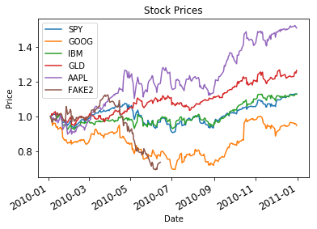

```python
 # Define a date range
start_date = '2010-01-01'
end_date = '2010-12-31'
dates = pd.date_range(start_date, end_date)

# Choose stock symbols to read
symbols = ['GOOG', 'IBM', 'GLD', 'AAPL', 'FAKE2']

# Get stock data
"""Read stock data (adjusted close) for given symbols from CSV files."""
df = pd.DataFrame(index=dates)
 # add SPY for reference, if absent
if 'SPY' not in symbols:
    symbols = ['SPY'] + symbols

for symbol in symbols:
    df_temp = pd.read_csv(os.path.join("./Data/", "{}.csv".format(str(symbol))), index_col='Date',
            parse_dates=True, usecols=['Date', 'Adj Close'], na_values=['nan'])
    df_temp = df_temp.rename(columns={'Adj Close': symbol})
    df = df.join(df_temp)
    if symbol == 'SPY':  # drop dates SPY did not trade
        df = df.dropna(subset=["SPY"])

# Normalize the stock data
df = df/df.iloc[0,:]

# Slice and plot
"""Plot stock prices with a custom title and meaningful axis labels."""
ax = df.plot(title="Stock Prices", fontsize=12)
ax.set_xlabel("Date")
ax.set_ylabel("Price")
plt.show()
```

**Statistical Analysis of Time Series:**

**Rolling Statistics:** A Bollinger Band® is a technical analysis tool defined by a set of lines plotted two standard deviations (positively and negatively) away from a simple moving average (SMA) of the security's price, but can be adjusted to user preferences. Bollinger Bands® were developed and copyrighted by famous technical trader John Bollinger.

**Daily Return:** Daily return is the profit/loss made by the stock compared to the previous day.

**Cumulative Return:** While daily returns are useful, it doesn't give immediate insight into the gains he had made till date, especially if the stock is very volatile. Cumulative return is computed relative to the day investment is made. If cumulative return is above one, you are making profits else you are in loss.

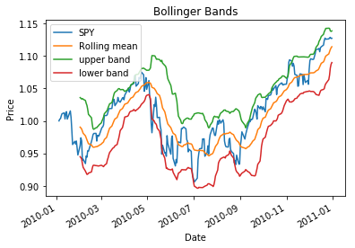

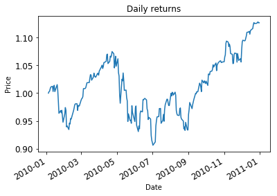

```python
# Compute Bollinger Bands for SPY
# 1. Compute rolling mean
rm_SPY = df['SPY'].rolling(window=20).mean()

# 2. Compute rolling standard deviation
rstd_SPY = df['SPY'].rolling(window=20).std()

# 3. Compute upper and lower bands
upper_band = rm_SPY + rstd_SPY*2
lower_band = rm_SPY - rstd_SPY*2

# Plot raw SPY values, rolling mean and Bollinger Bands
ax = df['SPY'].plot(title="Bollinger Bands", label='SPY')
rm_SPY.plot(label='Rolling mean', ax=ax)
upper_band.plot(label='upper band', ax=ax)
lower_band.plot(label='lower band', ax=ax)

# Add axis labels and legend
ax.set_xlabel("Date")
ax.set_ylabel("Price")
ax.legend(loc='upper left')
plt.show()

# Compute and plot daily returns for SPY and XOM
daily_returns = df.pct_change()
daily_returns.iloc[0,:] = 0
ax = df['SPY'].plot(title="Daily returns", fontsize=12)
ax.set_xlabel("Date")
ax.set_ylabel("Price")
plt.show()
```

**Processing Incomplete Data:** Stock data is an amalgamation from many sources. Stock data may be incomplete becase -  
● A stock may trade at different prices in NY Stock Exchange, another price as NASDAQ  
● There is no single price for any stock  
● Not all stock trade every day  
● Stocks come into existence and there’s values for them and before there was no data  
● Sometimes stocks go out of existence and suddenly they quit existing and there’s no data for them going forward  
● Sometimes stocks will be trading, data will be missing, then it starts trading again

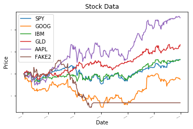

```python
"""Fill missing values in data frame, in place."""
df.fillna(method='ffill', inplace=True)
df.fillna(method='bfill', inplace=True)

"""Plot stock data with appropriate axis labels."""
ax = df.plot(title="Stock Data", fontsize=2)
ax.set_xlabel("Date")
ax.set_ylabel("Price")
plt.show()

df=df.drop(['FAKE2'], axis=1)
```

**Histogram of Daily Returns:** Kurtosis tells us about the tails of a distribution. If we assume that our histogram is similar to a gaussian Distribution or normal distribution, then the measure of Kurtosis tells us how different our histogram is from that of the traditional distribution.  
● If we measure a positive Kurtosis (fat tails) it means that there are more occurrences out in these tails than there are in the normal distribution.  
● If we measure a negative Kurtosis (skinny tails) it means that there are fewer occurrences out in these tails than there are in the normal distribution

Volatility is measured by the standard deviation of daily returns displayed using Histogram. Volatile stocks have return distributions that are very spread out. By contrast, low volatility stocks have tight distributions, where the daily returns are clustered around the average.

**Scatter Plots:** (the daily returns of that stock with respect to SPY) Beta - how reactive is the stock to the market. If the slope (Beta) is 1 it means that if the market goes up 1%, that stock also goes up 1%. If beta is 2, if the market goes up 1%, the stock goes up 2%. Alpha - That stock on average is performing a little bit better than the S&P500 (SPY) every day if Alpha is positive. If it’s negative it means it’s returned a little less than the market overall.

**The slope (Beta) is not Correlation!** Correlation is how tightly these individual points fit that line. So you could have a shallow slope with a higher correlation, or you can have a steeper slope and the data fitting the line at a higher correlation.

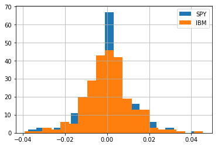

```
beta_IBM = 0.775793619638
alpha_IBM = 0.000127748793034
beta_GLD = 0.174111524354
alpha_GLD = 0.00088849783996
```

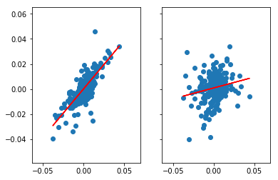

```
            SPY      GOOG       IBM       GLD      AAPL     FAKE2
SPY    1.000000  0.645624  0.781870  0.188838  0.708942  0.366556
GOOG   0.645624  1.000000  0.491159  0.107257  0.587580  0.182086
IBM    0.781870  0.491159  1.000000  0.152978  0.606308  0.296998
GLD    0.188838  0.107257  0.152978  1.000000  0.196127  0.026616
AAPL   0.708942  0.587580  0.606308  0.196127  1.000000  0.172606
FAKE2  0.366556  0.182086  0.296998  0.026616  0.172606  1.000000
```

```python
# Plot both histograms on the same plot
daily_returns["SPY"].hist(bins=20, label="SPY")
daily_returns["IBM"].hist(bins=20, label="IBM")
plt.legend(loc="upper right")
plt.show()

# Scatterplot SPY vs. XOM and SPY vs. GLD and the respective best fitting lines
# Two subplots appear side by side
f, (ax1, ax2) = plt.subplots(1, 2, sharey=True)

# The first subplot SPY vs. XOM and its best fitting line
ax1.scatter(daily_returns["SPY"], daily_returns["IBM"])
beta_IBM, alpha_IBM = np.polyfit(daily_returns["SPY"], daily_returns["IBM"], 1)
print ("beta_IBM = {}\nalpha_IBM = {}".format(beta_IBM, alpha_IBM))
ax1.plot(daily_returns["SPY"], beta_IBM*daily_returns["SPY"] + alpha_IBM, "-", color="r")

# The first subplot SPY vs. GLD and its best fitting line
ax2.scatter(daily_returns["SPY"], daily_returns["GLD"])
beta_GLD, alpha_GLD = np.polyfit(daily_returns["SPY"], daily_returns["GLD"], 1)
print ("beta_GLD = {}\nalpha_GLD = {}".format(beta_GLD, alpha_GLD))
ax2.plot(daily_returns["SPY"], beta_GLD*daily_returns["SPY"] + alpha_GLD, "-", color="r")

plt.show()

# Calculate the correlation coefficient
print (daily_returns.corr(method="pearson"))
```

**Portfolio Statistics:** To assess the performance of portfolio following statistics are tracked -

- Cumulative return
- Average period return (if sampling frequency == 252 then this is average daily return)
- Standard deviation of daily returns
- Sharpe ratio of the overall portfolio, given daily risk free rate (usually 0), and yearly sampling frequency (usually 252, the no. of trading days in a year)
- Ending value of the portfolio

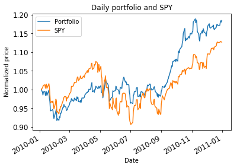

```
('Start Date:', '2010-01-01')
('End Date:', '2010-12-31')
('Symbols:', ['SPY', 'GOOG', 'IBM', 'GLD', 'AAPL'])
('Allocations:', [0.2, 0.3, 0.4, 0.1])
('Sharpe Ratio:', 1.2958146083104558)
('Volatility (stdev of daily returns):', 0.008727709921144678)
('Average Daily Return:', 0.0007124311574320947)
('Cumulative Return:', 0.18437235861414458)
('End value:', 1184372.3586141446)
```

```python
allocations = [0.2, 0.3, 0.4, 0.1]
start_val = 1000000
risk_free_rate = 0.0
sample_freq = 252

prices = df[['GOOG', 'IBM', 'GLD', 'AAPL']]  # only portfolio symbols
prices_SPY = df["SPY"]  # only SPY, for comparison later

# Get daily portfolio value
# Normalize the prices according to the first day
norm_prices = prices/prices.iloc[0,:]

# Compute prices based on the allocations
alloc_prices = norm_prices * allocations

# Calculate position values
pos_vals = alloc_prices * start_val

# Get daily portfolio value
port_val = pos_vals.sum(axis=1).to_frame()
port_val.columns = ["port_val"]

# Get portfolio statistics (sddr == volatility)
cr = port_val.iloc[-1, 0]/port_val.iloc[0, 0] - 1

#Compute daily returns
daily_returns = port_val.pct_change()
daily_returns.iloc[0,:] = 0
daily_returns = daily_returns[1:]

adr = daily_returns["port_val"].mean()
sddr = daily_returns["port_val"].std()
sr = np.sqrt(sample_freq) * (adr - risk_free_rate) / sddr

# Compare daily portfolio value with SPY using a normalized plot
# Create a temporary dataframe with both the SPY and Portfolio
df_temp = pd.concat([port_val, prices_SPY], keys=["Portfolio", "SPY"], axis=1)
df_temp.columns=["Portfolio", "SPY"]

# Normalize the data
df_portval = df_temp/df_temp.iloc[0,:]

# Plot the normalized data
ax = df_portval.plot(title="Daily portfolio and SPY", fontsize=12)
ax.set_xlabel("Date")
ax.set_ylabel("Normalized price")
plt.show()


ev = port_val.iloc[-1, 0]

# Print statistics
print ("Start Date:", start_date)
print ("End Date:", end_date)
print ("Symbols:", df.columns.values.tolist())
print ("Allocations:", allocations)
print ("Sharpe Ratio:", sr)
print ("Volatility (stdev of daily returns):", sddr)
print ("Average Daily Return:", adr)
print ("Cumulative Return:", cr)
print ("End value:", ev)
```

**Portfolio Optimization:** The simplest way to optimize the portfolio is to compare Cumulative return of stocks that maximized return over that time period. The allocation would be 100% to the highest returning stock.

But if you want to optimize for minimum volatility or Sharpe ratio you have to evaluate various combinations of those stocks. In order to use an optimizer that minimizes we need to do the following:

- Provide a function to minimize f(x)
- Provide an initial guess for x
- Call the optimizer
- And we want the optimizer to try different allocations to discover the best set of allocations that optimizes this function
- We want to optimize for Sharpe ratio, but f(x) is not the actual Sharpe ratio value, we want to optimize for -1 * the largest Sharpe ratio because the available optimizer function is minimize
- This will find the best allocation or the best value for x to solve this problem
- x can have multiple dimensions and each of the dimensions is the percentage of funds to allocate to each of those stocks

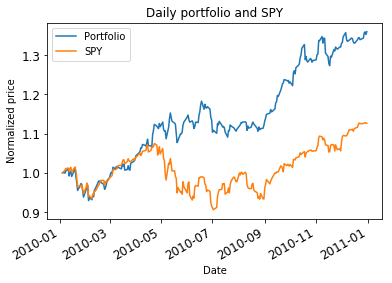

```
('Start Date:', '2010-01-01')
('End Date:', '2010-12-31')
('Symbols:', ['SPY', 'GOOG', 'IBM', 'GLD', 'AAPL'])
('Allocations:', [0.2, 0.3, 0.4, 0.1])
('Sharpe Ratio:', 2.004014991574243)
('Volatility (stdev of daily returns):', 0.01011606897217242)
('Average Daily Return:', 0.0012770634558667364)
('Cumulative Return:', 0.36007837173633916)
('End value:', 1360078.3717363402)
```

```python
#Function to optimize
def get_negative_sharpe_ratio(allocs, prices, sv=1000000, rfr=0.0, sf=252):
    # Get daily portfolio value
    # Normalize the prices according to the first day
    norm_prices = prices/prices.iloc[0,:]

    # Compute prices based on the allocations
    alloc_prices = norm_prices * allocs

    # Calculate position values
    pos_vals = alloc_prices * sv

    # Get daily portfolio value
    port_val = pos_vals.sum(axis=1).to_frame()
    port_val.columns = ["port_val"]

    # Get portfolio statistics
    cr = port_val.iloc[-1, 0]/port_val.iloc[0, 0] - 1

    #Compute daily returns
    daily_returns = port_val.pct_change()
    daily_returns.iloc[0,:] = 0
    daily_returns = daily_returns[1:]

    adr = daily_returns["port_val"].mean()
    sddr = daily_returns["port_val"].std()
    sr = np.sqrt(sample_freq) * (adr - risk_free_rate) / sddr
    neg_sr = sr * (-1)

    return neg_sr

bounds = ((0,1),(0,1),(0,1),(0,1))

constraints = ({'type': 'eq', 'fun': lambda x:  np.sum(x)-1.0})

initial_guess = np.ones((len(['GOOG', 'IBM', 'GLD', 'AAPL'])), dtype=np.float32)/(len(['GOOG', 'IBM', 'GLD', 'AAPL']))

result = spo.minimize(get_negative_sharpe_ratio, initial_guess, args=(prices,), method='SLSQP', constraints=constraints, bounds=bounds)
allocs = result.x

norm_prices = prices/prices.iloc[0,:]

# Compute prices based on the allocations
alloc_prices = norm_prices * allocs

# Calculate position values
pos_vals = alloc_prices * start_val

# Get daily portfolio value
port_val = pos_vals.sum(axis=1).to_frame()
port_val.columns = ["port_val"]

cr = port_val.iloc[-1, 0]/port_val.iloc[0, 0] - 1

#Compute daily returns
daily_returns = port_val.pct_change()
daily_returns.iloc[0,:] = 0
daily_returns = daily_returns[1:]

adr = daily_returns["port_val"].mean()
sddr = daily_returns["port_val"].std()
sr = np.sqrt(sample_freq) * (adr - risk_free_rate) / sddr

df_temp = pd.concat([port_val, prices_SPY], keys=["Portfolio", "SPY"], axis=1)
df_temp.columns=["Portfolio", "SPY"]
# Normalize the data
df_portval = df_temp/df_temp.iloc[0,:]

# Plot the normalized data
ax = df_portval.plot(title="Daily portfolio and SPY", fontsize=12)
ax.set_xlabel("Date")
ax.set_ylabel("Normalized price")
plt.show()

ev = port_val.iloc[-1, 0]

# Print statistics
print ("Start Date:", start_date)
print ("End Date:", end_date)
print ("Symbols:", df.columns.values.tolist())
print ("Allocations:", allocations)
print ("Sharpe Ratio:", sr)
print ("Volatility (stdev of daily returns):", sddr)
print ("Average Daily Return:", adr)
print ("Cumulative Return:", cr)
print ("End value:", ev)
```

Choosing a portfolio from among the enormous range of assets now available to an investor would be facilitated if we could locate the return– risk ratio of a particular allocation along a spectrum of possibilities. A comparison between portfolio choices can tell us, for example, whether it is better to select a suboptimal portfolio from a large class of assets or to perform a Markowitz optimal procedure on a subset of the assets. A common criterion for this assessment is the expected return-to-risk tradeoff as measured by the Sharpe ratio.